# Data QC with Visualization

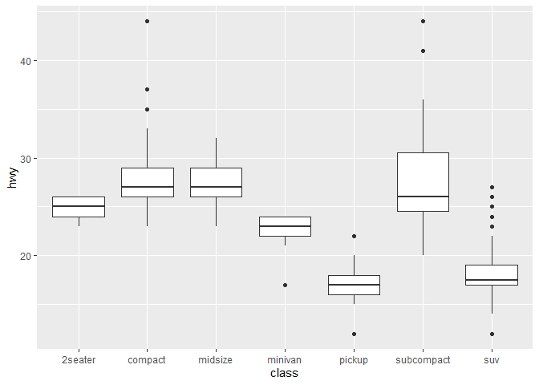

```r
ggplot(data = mpg, mapping = aes(x = class, y = hwy)) + geom_boxplot()
```

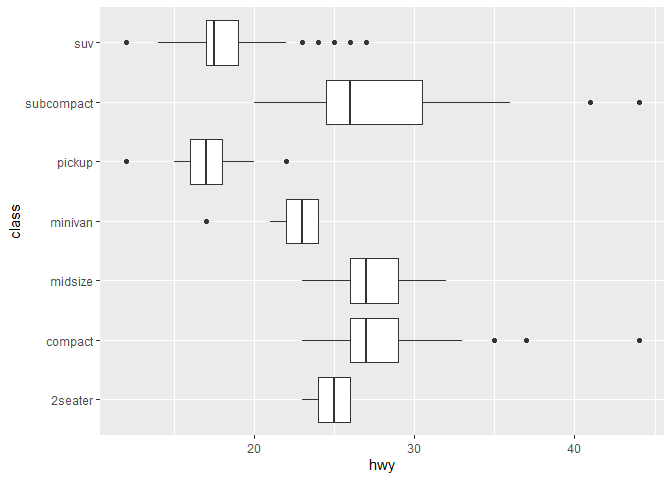

```r
ggplot(data = mpg, mapping = aes(x = class, y = hwy)) + geom_boxplot() + coord_flip()
```

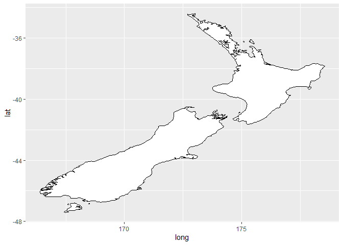

```r
nz <- map_data("nz")
ggplot(nz, aes(long, lat, group = group)) + geom_polygon(fill = "white", colour = "black")
```

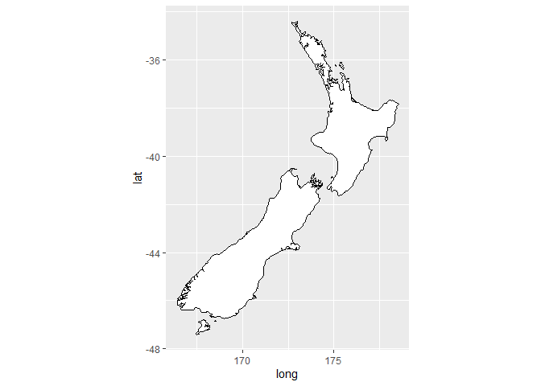

```r
ggplot(nz, aes(long, lat, group = group)) + geom_polygon(fill = "white", colour = "black") + coord_quickmap()
```

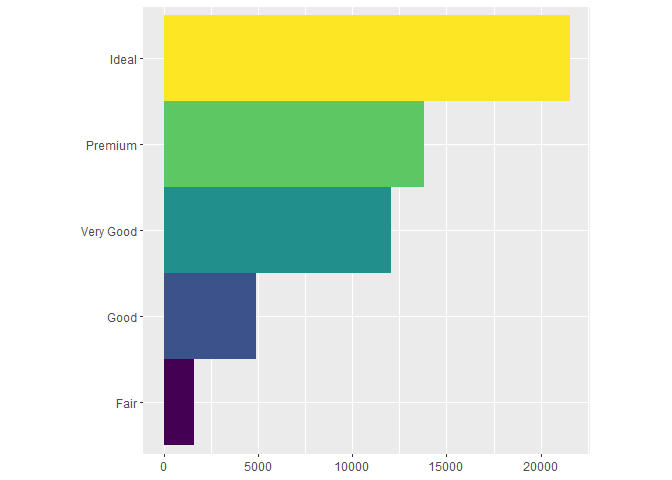

```r
bar <- ggplot(data = diamonds) + geom_bar( mapping = aes(x = cut, fill = cut), show.legend = FALSE, width = 1) +
theme(aspect.ratio = 1) + labs(x = NULL, y = NULL)

bar + coord_flip()
```

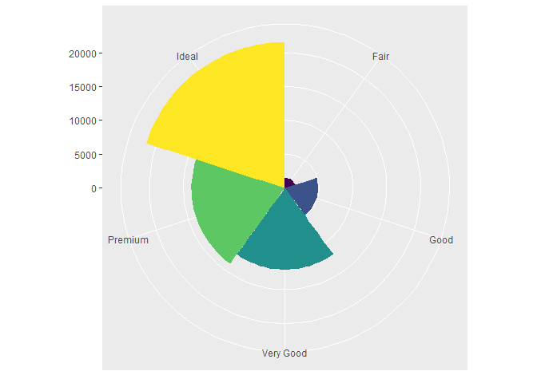

```r
bar + coord_polar()
```

# Exercise

1. Which variables in diabetes are categorical? Which variables are continuous?
2. Which plot do you want to use for each variable’s distribution?
3. Relationship across different variables? BMI vs Glucose, BMI vs Blood pressure, Age vs BMI, and so on
4. Play with the plot that you created in 3). How about adding `color=` by outcome variable, pregnancies? How about using color with continuous variable? How are they different?
5. Using facet to split the plot from 3) by different category.